# Progress Memo 2

Final Project  
Data Science 1 with R (STAT 301-1)

Author

Sana Nanlawala

Published

November 22, 2023

## Github Repo Link

https://github.com/stat301-1-2023-fall/final-project-1-SanaNanlawala2026.git

## Data Cleaning

The raw data originally contained **many** repetitive variables that could be combined into one variable. Originally the bar_pass_prediction dataset with 22407 observations on American students that entered law school in 1991 (this study was collected over several year, allowing the data collectors to gather information on whether these students graduated, passed the bar, etc) had 39 variables. However I was able to limit this to 12 variables.

### Variables Kept and Adjusted:

A lot of the factors, values, needed cleaning to be consistent with similar factor types across the dataset. This can be explored further in the clean_data.R file. There were also several variables in the raw dataset that were not given any explanation to their meaning (after extensive research)

## Univariate Analysis and General Distributions

Univariate analysis is proving to be the most confusing part of my dataset project because there is little information beyond identity of the students that are observed in this dataset. I feel that a lot of these analyses will be used for multivariate analyses later on, but I am including them here nonetheless.

One of the variables I have done an analysis on is the birth year of the students. These students were all born sometime in the 1900s. Below is a simple graphic.

[figure not shown]

We can see that this chart is left-skewed which makes most sense because you have to have gone to college before law school, and most college students are near the age of 18 when entering and 21-22 when leaving. However we have quite a few ouliers with people born as early as the 1920s. This could be a ‘bad’ observation but I will file it under people who are really interested in law, very late in their lives. I would love to see graduation rates in comparison to age as well as other variables against their birth year. Note: I am considering ‘cleaning’ my data further to just make the birth year into the age entering law school (i.e. age in 1991) in the future.

## Multivariate Analysis

### Graduation Status vs. Bar Exam Pass

To explore students who graduated or did not graduate law school and if they passed the bar exam, I constructed a simple bar plot. First I had to omit observations that had any missing values, especially if students didn’t graduate law school and CHOSE not to attempt the bar exam. (Remember this dataset shows students who at least attempted law school, i.e. entered law school in fall of 1991).

Below shows the chart:

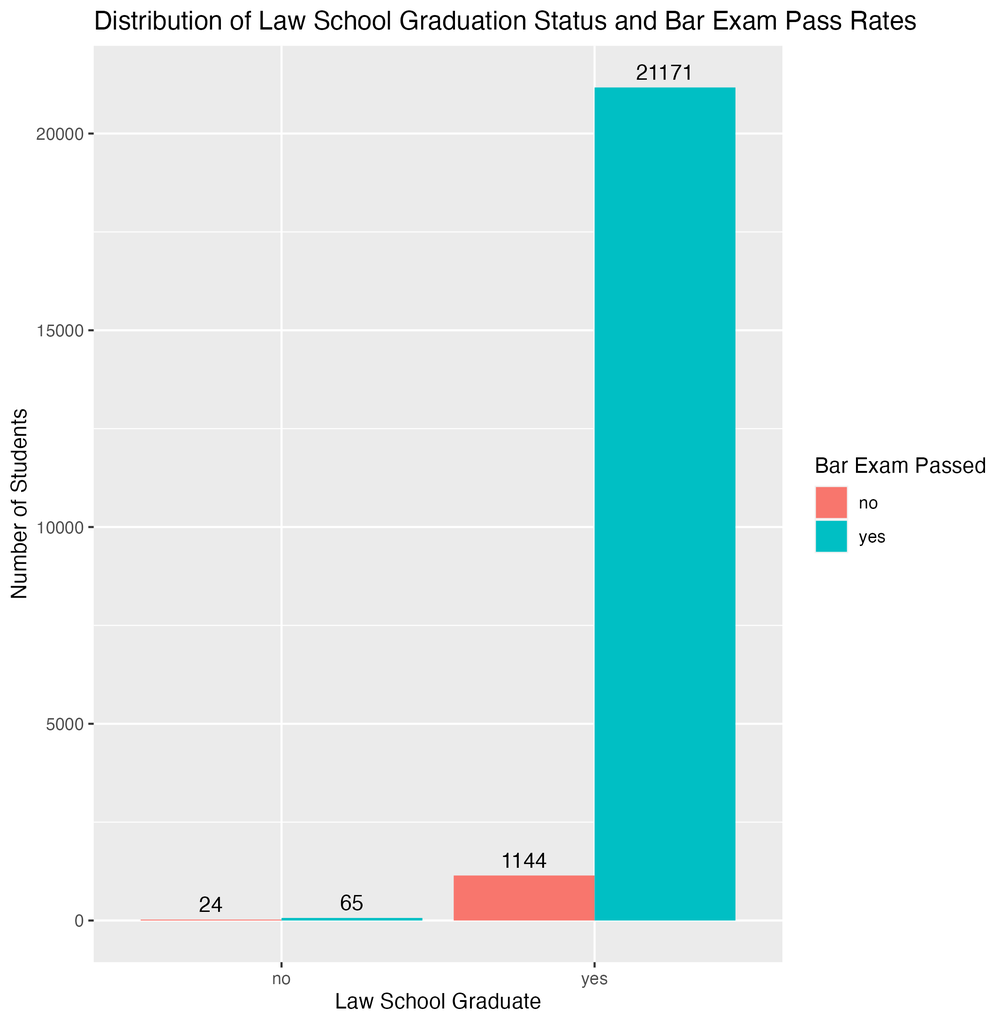

This may be surprising to some, to see a small amount of students who had not graduated and attempted the bar exam (with some even passing!). This is because there are some states that require some amount of law school (as in, not the full three years). These states are New York, Maine, and West Virginia. The 65 students who passed the bar and the 24 students who didn’t pass the bar (both groups not graduating law school), must have tried for their bar exam in any of these states.

There are also states that do not require ANY law school to attempt the bar exam which are California, Vermont, Virginia, and Washington. However this dataset are all observations of students who entered law school in 1991 so it is not applicable (unless the student immediately dropped out, but that information is not available)

### Family Income vs. Law School Tier

Law school tiers (1 is the highest) is established by clusters 1-6 with ugpas and LSAT scores (highest to lowest). This is something I found after some research and will likely change the name of the variable in the future (or maybe remove this variable entirely and separate the comparison of fam_inc with lsat and ugpa separately)

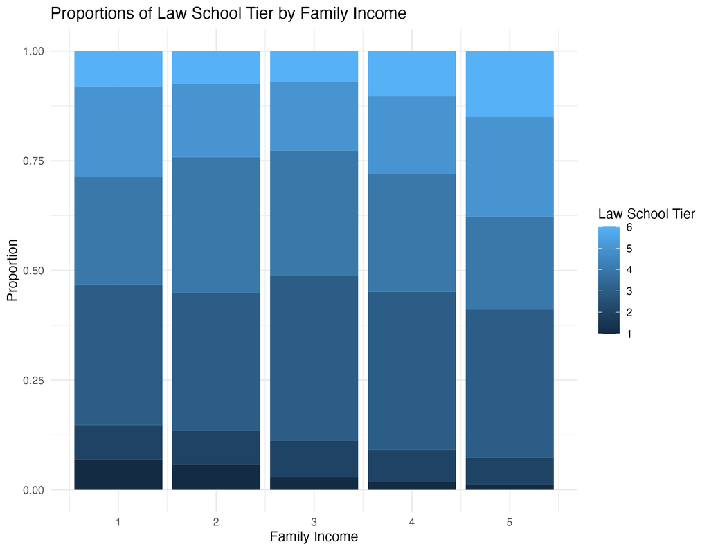

This information is not entirely useful until you look closely at the count of each family income level. (1 being the smallest, 5 the highest)

| fam_inc | count |
| --- | --- |
| 1 | 452 |
| 2 | 2176 |
| 3 | 7863 |
| 4 | 9732 |
| 5 | 1804 |

Clearly there is a large difference in the amount of students in this dataset that are in the first family income level vs the others (with the fourth highest income level having the most students). While this does speak to the idea that law school is a financial commitment, we are not sure how much of the students’ families are contributing to their tuition, but having a certain SES status growing up may impact your decision to apply/enter law school for sure.

Looking at the student distribution among law schools (with tier 1 having students with the highest average undergraduate gpa and LSAT scores)

| law_school_tier | count |
| --- | --- |
| 1 | 585 |
| 2 | 1675 |
| 3 | 7892 |
| 4 | 6020 |
| 5 | 3829 |
| 6 | 2026 |

I would like to continue this analysis further by finding the percent of students in each family income group going to each tier of law school. Currently this analysis is incomplete.

### Race vs. Family Income

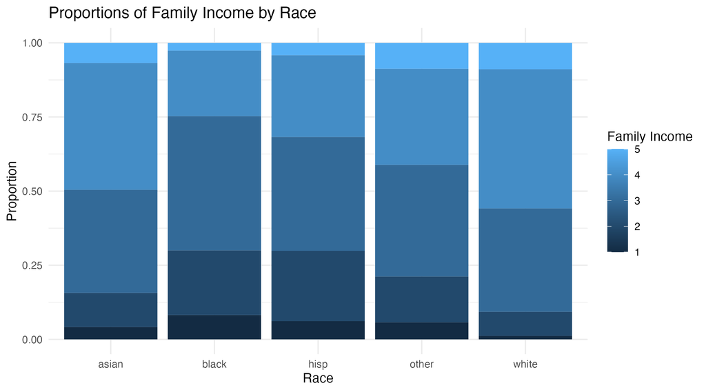

### Family income vs. Fulltime Status

I wanted to explore whether there is a trend between students from different family incomes being in law school fulltime or parttime. I am struggling to find a way to best share a visualization that shows this (the issue is that the family income, while numeric, is just five factors 1-5). Currently here is a histogram.

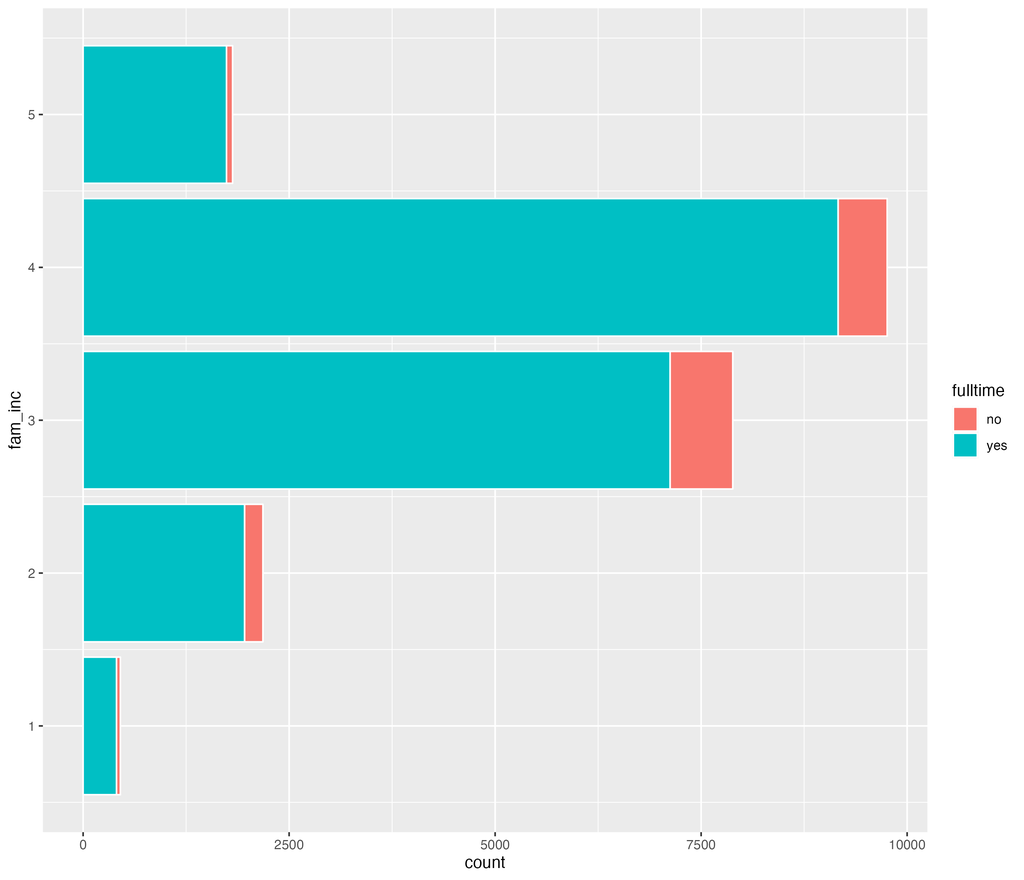

## For the future:

I really want to narrow this project down in terms of relations between variables for the sake of having one direction with this project, but I feel that limiting myself is not something that will encompass all the different things that can be explored with this data. This means that I will likely have many different conclusions pertaining to different things, which I am hoping is fine.

In terms of actual work: I want to do more obvious multivariate analyses as well as fix the formatting on all of my graphics with the labs() function. I want to cite my sources, create a codebook, executive summaries, and finalize the rest of the objectives in this project. I think I have a good understanding with what this data ‘is’, how it was collected, what each variables mean (after a long time of research) which has made things a lot smoother.

## References

I have not done proper citations, however I am keeping a list for my self in the future. https://www.juriseducation.com/blog/can-you-take-the-bar-exam-without-going-to-law-school

https://archive.lawschooltransparency.com/reform/projects/investigations/2015/documents/NLBPS.pdf